# Data-Reanalysis-Assignment

Arora

December 9, 2017

# Replication of Ellefsen and Smith 2016

## Introduction

##### The following is the reanalysis of Ellefsen and Smith’s 2016 paper Manuel hierarchical clustering of regional geochemical data using a Bayesian finite mixture model.

##### In this study the authors use a Bayesian finite mixture model to cluster geochemical data from a USGS survey of soil geochemistry in Colorado. They use this Bayesian model instead of another clustering technique, because a Bayesian model has yet to be used in this type of research.

##### Their goal is to understand geochemical processes occuring at different spacial scales. To do this, they use a hierarchical modeling to create two clusters of the data, with the goal of breaking those clusters into two more clusters, and so on. Each set of clusters should represent different geologic, climatic, and biological processes occuring at different spacial scales. Clustering is a useful technique in geochemical analysis because this type of survey data can encompass thousands of samples with many elements measured (in this study they begin with 44 elements).

##### To derieve the parameters for their model they use the Monte Carlo sampling and then check each model against previously known geologic information. The model which best fits that previous knowledge is used for the analysis.

## Dataset

##### The dataset used in the paper and in this replication can be found in the GcClust package which can be download from https://pubs.er.usgs.gov/publication/tm7C13 .

##### The dataset for this paper was collected for a USGS (United States Geological Service) survey of soil geochemistry in the state of Colorado. The original dataset for this study consisted of 966 samples with 44 elements measured. Six samples were excludeded because of issues with their location and one was removed because of anthropogenic effects. Five elements were removed because their measured concentrations often fell below their detection limits. This leaves 959 samples with 39 measured elements.

## Outline of Analyses

##### Overall the analyses that they conduct are: (1) determing number of principal components, (2) checking the posterior probability function using the plots of their traces, (3) use 95% confidence intervals of means, standard deviations, proportions, and log-likelihood to select chains for further analyses, (4) use posterior predictive p-values and 95% confidence interval to check their model, (5) analyze correlation between principal components and variation using posterior predictive p-values, (6) create 95% confidence intervals to distinguish one probability density function from the other, (7) view standard deviation of the log-ratios between elements, (8) partion their data based on all those analyses into two clusters.

##### I will complete steps 1-9 below.

##### 1. Transform compositional data in isometric log-ratio (ilr) coordinates, and transform the ilr coordinates with the robust principle components transform.

##### 2. Select a subset of components.

##### 3. Use Monte Carlo Sampling to produce the chains.

##### 4. Select chains for furthur anslysis.

##### 5.Combining the chains and switching them into their proper place. (The switching could not be done for reasons stated below).

##### 6. Calculate conditional probability that field sample is associated with the first probability density function in the finite mixture model.

##### 7. Plot the observed statistics calculated from the conditional probability to check the observed statitics against the calculated statistics.

##### 8. Transform the observed data into simplex, which is compositional center and variation matrix.

##### 9. Visualize the data using the compositional centers, variaiton matrices, and a map of the relationship between the sample and the probability density function.

##### 10.The samples which were partioned into the two probability density functions are put into two separate datasets. The analysis of each of these new datasets begins again to create the hierarchy of clusters. I have not included this because it is just putting the data into two separate tables.

## Compositional Data

##### Compositional data is always postive and adds up to 100% and in geology is often derieved from counts data which is scaled into the units of concentration. One of the problems with compositional data is that because all the data is in the positive real space, measures such as variance are considered impractical. This particular issue is called the constraint problem and can be solved through a transformation. Currently the most robust though statistically least understood method for transformation is the isometric log-ratio transformation. Like most transformations, it is difficult to relate the results after the transformation has taken place with the original dataset. For this reason compositional data should be analyzed in the following way: (1) transform the data, (2) perform any desired statistical analyses, (3) analyze the results, usually by transforming back into the original units.

## Reanalysis

##### First download and open the following packages: {colorspace}, {GcClust}, {ggplot2}, {maps}, {mvtnorm}, {reshape2}, {robustbase}, {rstan}, {sp}, {shiny}

```r
library(colorspace)
```

```r
library(GcClust)
library(ggplot2)
library(maps)
library(mvtnorm)
library(reshape2)
library(robustbase)
library(rstan)
library(sp)
library(shiny)
```

##### As per the instructions within the supplementary information for the paper, add dataset into gcData. The dataset used for their study is available in the GcClust package as CoGeochemData.

```r
gcData<-CoGeochemData
#the data needs to be put into gcData because many of the functions (found on their github site here: https://github.com/USGS-R/GcClust/blob/master/R/GcClusterFunctions.R) require the dataset to be in a list called gcData.
#they describe how to format the data in their user guide (https://github.com/geochemica/data-reanalysis-assignment/blob/master/GcClust_User_Guide.pdf). Each sample should have a unique identifer, coordinates, and concentration for each element present.
head(gcData)
```

[output not shown]

[output cut: 7631 more lines]

[output not shown]

##### The following is a map of the points where samples were taken. This map isn’t necessary for the analysis.

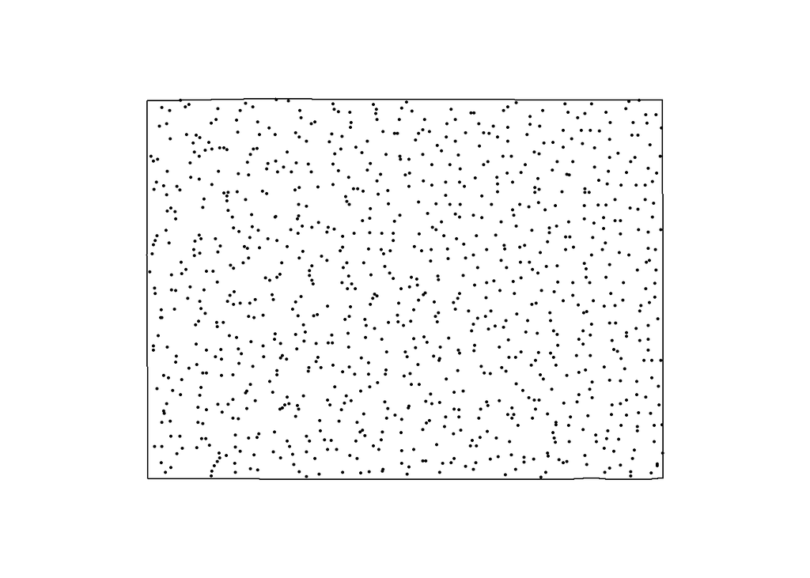

```r
maps::map(database="state", regions = "Colorado", fill=FALSE)
plot(gcData$concData, add = TRUE, pch =
16, cex = 1/3)
```

```r
#their original code had fill, a white border, and red points however I could not get that particular code to work so I edited so the points were back and the fill was removed.
```

[figure not shown]

###### This is the map Ellefsen and Smith included in their paper.

##### Step 1: Transform the concentration data first by isometric log-ratio (ilr) transform and then the robust principle components transform. The ilr transform changes the data into a form that can be clustered. The robust principle components transform is done because the authors assume it will make the following model more stable by reducing the number of dimensions. Both transformations occur within the transformGcData function.

```r
transData<-transformGcData(gcData)
```

##### Step 2: Select the number of principle components. The authors present several plots to determine the number of principle components they will use. However, they decide to use the cumulative method, which is when the analyst keeps adding principle components until a certain percentage of the dataset is selected for. For the purpose of replicating their study I have followed their example.

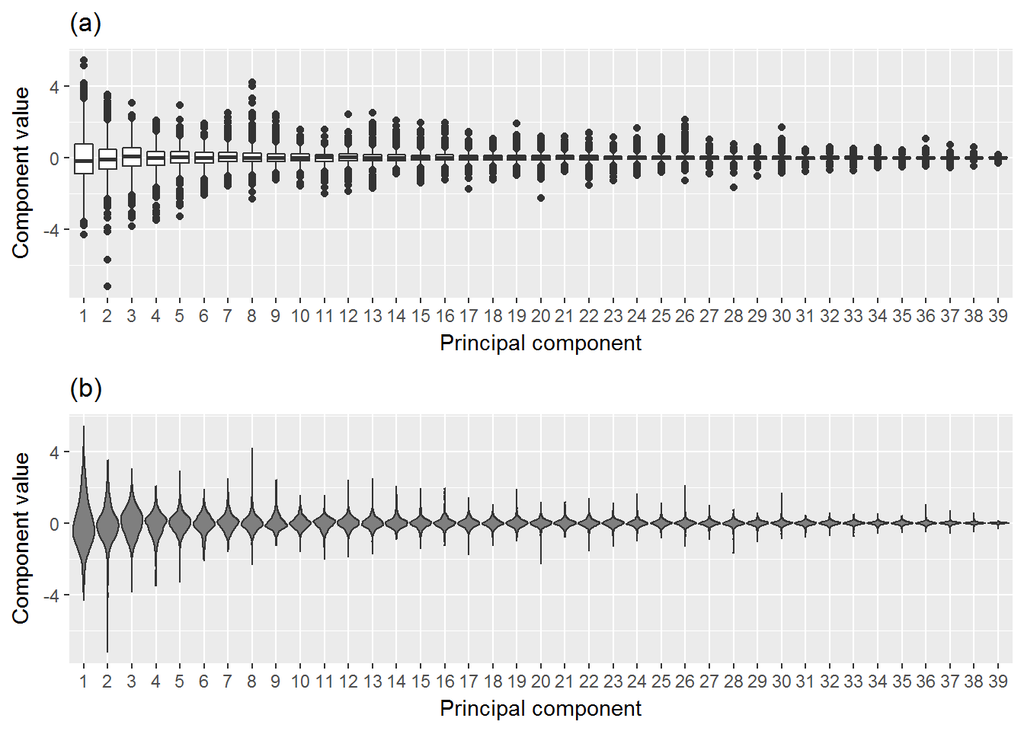

[figure not shown]

```r
plotEdaDist(transData)
```

###### The plot above is from their paper and user guide to GcClust. Their plot and my plot should look exactly the same.

##### I did not find this particular graph helpful when attempting to determine the number of principle components to select.

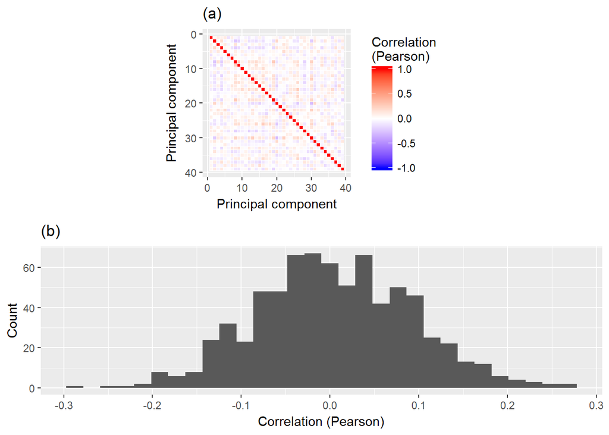

[figure not shown]

```r
plotEdaCorr(transData)
```

###### This is a correlation matrix of the principle components using the Pearson’s correlation coefficient, which is like R-squared, so a -1 is exactly negative correlation, a zero is no in either direction correlation, and a +1 is complete positive correlation. However if this graph works like the same type of graph below (that graph is the matrices used for model checking, their figure 8 which is included below), then the graph should look very similar across the red diagonal, and the value of the coefficient is not really taken into account. Their graph does look very similar across the diagonal.

##### I also did not find these graphs helpful when attempting to determine principle components. When I begin to edit the functions and add in my own dataset, I will disregard these graphs.

##### This is the scree plot. In R in Action a scree plot is described as one way of determing the number of principle components to keep for analysis. While Ellefsen and Smith (2016) decide to use add up principle components until they come up with a certain value, a scree plot is uses a matrix of Eigenvalues versus the component. Depending on the type of scree test performed, the user is either looking for a bend or “elbow” in the graph or the number of components where the eigenvalue is less than one. Because the eigenvalues were not plotted, instead we will look for the dip to determine the number of princpal componetns as well as the cumulative variance we want to account for. And while choosing 39 principle components will describe all the data, we perform principle components analysis to essentially reduce the number of variables.

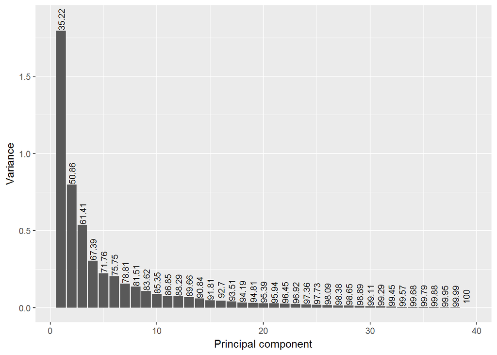

[figure not shown]

```r
plotEdaVar(transData)
```

```r
nPCs <- 22
```

##### Step 3: Use the mixture model. This file formated according to their User Guide for GcClust, included in my data-reanalysis repository. I have little experience with Bayesian statistics and no knowledge of the stan programming language, so I have yet to parse out what their code is actually doiong. Expect updates here.

```r
tmp<-normalizePath(path.package("GcClust"))
load(paste(tmp, "\\stan\\MixtureModel.bin", sep=""))
```

##### The following code is used to sample the chains, however I had to edit this code because R ran an error. This function is used in the samplePars function below. This code is available from their github repository, linked in the Works Cited section.

```r
sampleFmm <- function(transData, nPCs, sm,
                      priorParams,
                      nWuSamples = 500,
                      nPwuSamples = 500,
                      nChainsPerCore = 2,
                      nCores = 4,
                      procDir = ".") {


  rstanParallelSampler <- function(stanData, sm, nWuSamples, nPwuSamples,
                                   nChainsPerCore, nCores, procDir ) {

    CL <- parallel::makeCluster(nCores)

    parallel::clusterExport(cl = CL,
                            c("stanData", "sm", "nWuSamples", "nPwuSamples",
                              "nChainsPerCore", "procDir"),
                            envir=environment())

    fnlist <- parallel::parLapply(CL, 1:nCores, fun = function(cid) {

      # Make rstan available to the processors. This function won't work
      # otherwise. So, I'm violating the principles in "R packages",
      # p. 34, 82-84
      require(rstan, quietly = TRUE)

      fileNames <- vector(mode = "character", length = nChainsPerCore)

      for(i in 1:nChainsPerCore) {

        rng_seed <- sample.int(.Machine$integer.max,1)

        gen_inits <- function() {
          areInGrp1 <- sample(c(TRUE,FALSE), size = stanData$N,
                              prob = c(0.3, 0.7), replace = TRUE)
          return(list(
            theta = runif(1, min = 0.35, max = 0.65),
            mu1 = apply(stanData$Z[areInGrp1,], 2, mean ),
            mu2 = apply(stanData$Z[!areInGrp1,], 2, mean ),
            tau1 = apply(stanData$Z[areInGrp1,], 2, sd ),
            tau2 = apply(stanData$Z[!areInGrp1,], 2, sd ),
            L_Omega1 = diag(stanData$M),
            L_Omega2 = diag(stanData$M)
          ))
        }

        rawSamples <- rstan::sampling(sm, data = stanData,
                                      init = gen_inits,
                                      # control = list(stepsize = 0.00001),
                                      control = list(stepsize = 0.0001),
                                      # control = list(adapt_delta = 0.95),
                                      chains = 1,
                                      iter = nWuSamples + nPwuSamples,
                                      warmup = nWuSamples,
                                      seed = rng_seed, chain_id = cid,
                                      pars=c("theta", "mu1", "mu2",
                                             "tau1", "tau2",
                                             "L_Omega1", "L_Omega2", "log_lik")) #I removed save_dso=FALSE from this line because that gave me an error

        fileNames[i] <- paste("RawSamples", cid, "-", i, ".dat", sep = "")
        save( rawSamples, file = paste(procDir, "\\", fileNames[i], sep = "") )

      }
      return(fileNames)
    } )

    parallel::stopCluster(CL)
    return(unlist(fnlist))
  }

  if(priorParams[1] <= 1)
    stop("Element 1 of priorParams must be > 1.")

  if(priorParams[2] <= 0)
    stop("Element 2 of priorParams must be > 0.")

  if(priorParams[3] <= 0)
    stop("Element 3 of priorParams must be > 0.")

  if(priorParams[4] <= 1)
    stop("Element 4 of priorParams must be > 1.")

  if(nCores > parallel::detectCores())
    stop("The number of requested cpu's must be <= the number of actual cpu's.")

  stanData <- list( M = nPCs,
                    N = nrow(transData$robustPCs),
                    Z = transData$robustPCs[,1:nPCs],
                    priorParams = priorParams )

  fileNames <- rstanParallelSampler(stanData, sm, nWuSamples, nPwuSamples,
                                    nChainsPerCore, nCores, procDir )

  return(list(nChains = nChainsPerCore * nCores,
              nWuSamples = nWuSamples,
              nPwuSamples = nPwuSamples,
              fileNames = fileNames))
}
```

##### Now its time to actually run the model. To do this the analyst needs to check how many cores he or she has. To do this open up the library {parallel} and run detectCores(). I have four cores and decided to run 5 chains per core which took around 2.5 hours. The authors had more cores and ran a total of 35 chains which took them about 2 hours.

##### Our results will look different from here. However the code below will note run because this model cannot knit. I have included images of my own results and interpreted those results as I can find no way of load a .dat file into R. I wanted to load all the chains into samplePars and then run the rest of the code with those chains.

```r
priorParams <- c(4, 3, 3, 2)
samplePars <- sampleFmm(transData, nPCs,sm, priorParams, nChainsPerCore = 5, nCores = 4)
```

##### Step 4: Selecting the chains for furthur analysis. Currently there are 20 chains will 551 model parameters. To select the chains, first plot the chains.

```r
plotSelectedTraces(samplePars)
#I only included the picture of the first chain instead of all twenty (from the model I run prior to knitting) because adding all twenty seemed excessive
```

[figure not shown]

###### This is their image for the first chain. In the standard deviation vector, the second probability density function is switched with the first meaning that the red line, which is the second probability density funciton, in on the top portion of the graph while the blue line - the first probability density function - is on the bottom. This switch is okay because using their code we should be able to switch everything back into their right place. In their image the two lines never cross each other, which is what they are checking for. If the red and blue lines crossed, they would need to change the posterior probability density function.

[figure not shown]

###### In my first chain, the mean has the second probability density function switched and on top while the standard deviation has the second probability density function on top. This chain should be fine to analyze because the lines don’t cross

##### Next check each chain to select the model which best fits the data, which is not necessarily the model with the highest log-likelihood ratio.However, the authors do not explain how the models they selected best fit their previous geological knowledge about soils in Colorado

```r
plotPointStats(samplePars)
```

[figure not shown]

###### In their point statistics the first and third chains are switched.

[figure not shown]

###### In my plot the second and fourth chains are switched and would need to be switched back so that the second probability density function is below the first probability density function.

##### I too decided to choose the first four chains. Their explanation about how to choose modes that best fit the geochemical data was unclear and I continue to look for furthur resources about how to choose the best model given the previous information.

##### The csv file below allows the combinedChains function to combine the desired chains. I wrote into the csv for the second and fourth chains to be switched. All the information from the first probability density function should be on top of the information from the second probability function. Despite the switching not working, this is explained below, the results of the analysis are very similar. .

```r
selectedChains<-read.csv(file="https://raw.githubusercontent.com/geochemica/data-reanalysis-assignment/master/selectedChains.csv", header=TRUE, stringsAsFactors = FALSE)
```

```r
read.csv(file="https://raw.githubusercontent.com/geochemica/data-reanalysis-assignment/master/selectedChains.csv", header=TRUE, stringsAsFactors = FALSE)
```

```
##   Chain is.Switched
## 1     1       FALSE
## 2     2        TRUE
## 3     3       FALSE
## 4     4        TRUE
```

```r
combineChainz <- function(samplePars, selectedChains, procDir = ".") {
  sfList <- vector(mode = "list")
  for(k in 1:nrow(selectedChains)) {
    iChain <- selectedChains[k, "Chain"]
    load( paste(procDir, "\\", samplePars$fileNames[iChain], sep = ""))
    #all the text was removed to convert this statement from combineChains to combineChainz. The error was that an argument = 0.
    #if(selectedChains[k, "isSwitched"] == TRUE) {rawSamples@sim$samples[[1]]$theta <- 1 - rawSamples@sim$samples[[1]]$theta N <- rawSamples@par_dims$mu1
      #for(i in 1:N) {
        #var1 <- paste("rawSamples@sim$samples[[1]]$\"mu1[", i, "]\"", sep="")
        #tmp1 <- eval(parse(text = var1))
        #var2 <- paste("rawSamples@sim$samples[[1]]$\"mu2[", i, "]\"", sep="")
        #tmp2 <- eval(parse(text = var2))
        #eval(parse(text = paste(var1, " <- tmp2")))
        #eval(parse(text = paste(var2, " <- tmp1")))
        #var1 <- paste("rawSamples@sim$samples[[1]]$\"tau1[", i, "]\"", sep="")
        #tmp1 <- eval(parse(text = var1))
        #var2 <- paste("rawSamples@sim$samples[[1]]$\"tau2[", i, "]\"", sep="")
        #tmp2 <- eval(parse(text = var2))
        #eval(parse(text = paste(var1, " <- tmp2")))
        #eval(parse(text = paste(var2, " <- tmp1")))
        #for(j in 1:N) {
          #var1 <- paste("rawSamples@sim$samples[[1]]$\"L_Omega1[", i, ",", j, "]\"", sep="")
          #tmp1 <- eval(parse(text = var1))
          #var2 <- paste("rawSamples@sim$samples[[1]]$\"L_Omega2[", i, ",", j, "]\"", sep="")
          #tmp2 <- eval(parse(text = var2))
          #eval(parse(text = paste(var1, " <- tmp2")))
          #eval(parse(text = paste(var2, " <- tmp1"))) }}}
    sfList[[k]] <- rawSamples
  return(rstan::sflist2stanfit(sfList))
  }
}
```

##### This step combines the chains together so that we can use them for the next step. The if statement in their combineChains function did not work so I removed that statement and replaced their funciton with combineChainz (with a z).Despite the chains not switching into their correct places, the analysis below worked out very similar to their analysis.

```r
combinedChains<-combineChainz(samplePars, selectedChains, procDir = ".")
```

##### Step 6: Calculate the conditional probability of the field samples. The conditional probability and the number of principle components will allow for the calculation of the observed statistic set (which contains the means vector, standard deviations vector, and correlation matrices of the two densitiy functions). These are the observed dataset because they are derieved from the data while the calculated dataset is derived from the posterior probability density function.

```r
condProbs1 <- calcCondProbs1 (transData,nPCs, combinedChains)
```

##### This matrix is calculated from the 22 principle components and the conditional probabilities.

```r
obsTestStats <- calcObsTestStats (transData,nPCs, condProbs1)
```

##### To check the model we will compare the observed statistics (code right above this) with the replicated test statistics which we get from samples of the posterior probability density function.

##### In this study, the replicated test statistics are the same as the samples of the mean vectors, standard deviation vectors, and correlation coefficients that we combined together in CombinedChains. This figure also gives p value between the observed and replicated statistics.

```r
plotTMeanSd(combinedChains, obsTestStats)
```

[figure not shown]

###### This is Ellefsen and Smith’s means and standard deviation vectors for the first chain. The red dot is the test statistic and should be within the vertical black line and close to the horizonal black line. The vertical black line is the 95% confidence interval and the horizonal one is the median. It may be by design that the dot is so big that in every graph the red dot contains the median, though this may actually reflect the test statistic. The principal components in the standard deviation plots around principal componant 10 become about the same size as the dot but all the dots are defined by the two black lines. The values above each confidence interval isthe posterior predictive p-value, which has a maximum value of 0.5.

[figure not shown]

###### These plots look very similar for both runs, except that mine looks more squat. This is surprising seeing as I did not switch any chains. The test statistics are also defined by the two black lines in my plots for both the mean vectors and the standard deviation vectors. The p-values in these plots are both difficult to see (apologies) but moderate to high with most around 0.4 for the mean vectors and 0.3 for the standard deviation vectors.

##### Now its time to compare the correlation matrices between the test statistics and the replicated statistics. This is another analysis with p-values and could be counted as inferential.

```r
plotTCorr(combinedChains, obsTestStats)
```

##### This set of four graphs looks very complex at first. Let’s first concentrate on the first and third graphs which are fully coloured and have the red diagonal line. The top right triangle of each graph represents the correlation matrix from the principle components. The bottom left triangle represents the correlation matrix from the replicated samples. The comparison between the two is do they look the same? In their case their graphs do look the same across the red line.

##### The two blue graphs which only fill the top right portion of the graph present the p-values. However these values will be mirror across the diagonal line so both sides are not shown. In this particular analysis, the largest possible posterior predictive p-value is 0.5 and so in their graphs the p-values are, as they state, moderate to large.

[figure not shown]

###### This is their correlation matrices for the probability density functions. For plots A and C, the values look similar across the red line. For plots B and D most of the squares are dark, showing that high p-values for each probability density function. Remember that the posterior predictive p-values have a maximum value of 0.5.

[figure not shown]

###### My plots look very similar to their with the plots on the left looking similar across the red line and moderate to high p values for the right two graphs.

##### The values from combinedChains (mean vector, standard deviation vector, and correlation matrices) are transformed in simplex. Simplex here refers to an algorithm in linear programming which helps with optimization. Expect updates here once I learn more about linear programming.

```r
simplexModPar <- backTransform (gcData,nPCs, transData, combinedChains)
```

##### This is reording the elements.I kept their order so that the results would be comparable, though this isn’t the order I would have chosen.

```r
elementOrder <- c("Sr", "U", "Y", "Nb", "La", "Ce", "Th", "Na", "Al", "Ga","Be", "K", "Rb", "Ba", "Pb", "Cu", "Zn", "Mo", "Mg", "Sc", "Co", "Fe", "V", "Ni","Cr", "Ca", "P", "Ti", "Li", "Mn", "Sn","As", "Bi", "Cd", "In", "S", "Sb", "Tl","W", "EE")
```

##### Using the elementOrder decided on above, median of the compositional centers for each element (the compositional centers is a vector) is plotted. This graph is useful because the units are in concentration, making it easy to compare to other datasets.

```r
plotCompMeans(simplexModPar, elementOrder)
```

[figure not shown]

###### In the graph there are two dots: one red and one blue. For a particular element the blue dot represents the median concentration as calculated by the first probability density function, and the red dot presents the median concentration as calculated by the second probability density function. In some of the elements it is easy to make out that there is a large difference between the two probability density functions, however some elements are right on top of each other according to this scale. It’s for these reasons that the next transformation is done. This is Ellefsen and Smith’s compositional centers plot. Note how the values for thallium and antinomy are essentially on top of each other so indistinguishable

[figure not shown]

###### Note in my plot how the values for rubidium, potassium, and barium are also instituguishable.

##### Using simplex again, the statistics are translated to allow us to tell the difference between the medians of the first probability density function versus the second. Ellefsen and Smith also want to add additional information to the plot involving the replicated statistics.

```r
simplexStats <- calcSimplexStats(gcData)
```

##### This plot has thhe translated data which is cleared to read and has the addition of the 95% confidence interval. As always, blue represents the first probaility density function and red represents the second. The only problem is that with the transformation the units of concentration are lost.

```r
plotTransCompMeans(simplexModPar,simplexStats, gcData, elementOrder)
```

[figure not shown]

###### Note how due to the translation, we can now distinguish between the two probability density functions for thallium and antimony.

[figure not shown]

###### In my the centers for rhodium, potassium, and barium are no longer right on top of each other however because the units of concentration have been removed, this plot isn’t useful when trying to compare this dataset with others.]

##### The next visualization is the variation matrices for each probability density function. The variation matrix for the first probability density function is the upper right triangle and the matrix for the second is in the lower left triangle. This plot shows the standard deviation of the log-ratios between two elements.

```r
plotSqrtVarMatrices( simplexModPar,elementOrder, colorScale = "rainbow" )
```

[figure not shown]

###### In theirs variation matrix it looks like the variance is smaller in the second probability density function than in the first.

[figure not shown]

###### In my variation matrix it looks like the upper triangle has a higher standard deviation than the lower triangle.

##### The final visualization is the graph of the association between the field samples and the conditional probability matrix from the first probability density function (condProb1). The values used to assign the four categories are the median probabilities calculated from condProb1. The csv file below contains the key to interpreting the map and the median probabilities associated with each category.

```r
m<-read.csv(file="https://raw.githubusercontent.com/geochemica/data-reanalysis-assignment/master/MapKey.csv")
m
```

[output not shown]

```r
map(database = "state", regions = "colorado", fill = TRUE, col = "grey95", border = "white")
map.axes()
plotClusters(gcData, condProbs1, symbolSizes = rep.int(2/3, 4))
```

[figure not shown]

###### Their mode map is mostly blue and red.This means that their data is strongly associated with the first probability density function or moderately associated with the second probability density function.

[figure not shown]

###### Like their map, mine is also mostly blue and red. This means both our points are either strongly associated with the first probability function or moderately associated with the second.

##### From here the dataset is saved as two datasets: the one associated with probability density function 1 and the one which is associated with the second probability density function. The analysis, from determing the principle components is run again. Eventually the data is be partitioned in heirarchical clusters. The authors do a K-means analysis as well and the advantage of a K-means is that it will take much less time. However shoud their prior information truly be important in understanding the local and regional processes, then this Bayesian model would be better. This paper has been illustrative of all the things which I still need to learn to analyze my own data and once I hand this in I will begin applying this to my own work!

## Works Cited

##### Ellefsen, Karl J. and David B. Smith 2016. Manual hierarchical clustering of regional geochemical data using a Bayesian finite mixture model. Applied Jeochemistry 75: 200-2010.

##### Ellefsen, Karl J. and David B Smith 2016. User’s guide for GcClust - An R package for clustering of regional geochemical data: U.S.Geological Survey Techniques and Methods 7-C13, 21 p., http://dx.doi.org/10.3133/tm7c13

##### https://github.com/USGS-R/GcClust - everything from their functions to the stan model is found here. Any papers or information not in their repostitory has been uploaded onto my repository.

##### Kabacoff, Robert I. 2015. R in Action: Data analysis and graphics with R, Second Edition.Shelter Island, Manning.

##### Pawlosky-Ghan, Vera, J.J. Egozcue, and Raimon Tolosana-Delgado 2012. Modelinng and analysis of compositional data. Chichester, john Wiley and Sons, Ltd.

##### Simplex algorith. Wikipedia, accessed December 7, 2017. https://en.wikipedia.org/wiki/Simplex_algorithm